# MRP preferred model

davis

02/09/2021

### AES data preparation

AES data as prepared in earlier research. Note this dataset includes non-response levels for variables where there is non-response in the Census.

```r
## Install and attach packages
library ("arm")
library ("lme4")
library ("lmerTest")
library("tidyverse")
library("naniar")
library("MuMIn")
# load dataset
# We use the AES dataset (including non-responses as levels in relevant variables) as organised in MRP_electorate_analysis_2021.Rmd. The code below is replicated from MRP_electorate_analysis_2021.Rmd at lines 646-75.
detach(package:dplyr)
detach(package:tidyverse)
```

```r
data2 <- read.csv("aes19_amended2.csv", sep=",", stringsAsFactors = FALSE)
# recode 999 as NA
data2 <- data2 %>% replace_with_na_all(condition = ~.x == 999)
data2 <- data2 %>% replace_with_na_all(condition = ~.x == "999")
# subset the data to include only cases where citizenship is Australian or not stated (there are 8 cases of citzenship missing values in the AES data)
data2 <- subset(data2, citizen!=2)
# convert relevant variables to factors
data2$citizen <- as.factor (data2$citizen)
data2$lab2pp <- as.factor (data2$lab2pp)
data2$country_born <- as.factor (data2$country_born)
data2$gender <- as.factor (data2$gender)
data2$state_name <- as.factor (data2$state_name)
data2$ced_name <- as.factor (data2$ced_name)
data2$age_group <- as.factor (data2$age_group)
data2$education <- as.factor (data2$education)
data2$income <- as.factor(data2$income)
# create dependent variable coded TRUE for lab2pp = 2
data2$lab2pp.2 <- with(data2, lab2pp==2)
# create new four-level age group variable
# noting that the final cut-point of 104 reflects the highest age in the data being 103 and 999 being used for missing cases - the earlier coding of the four-level age variable inadvertently included the missing cases as instances of age_group4 level 4
data2$age_group4 <- cut(data2$age, c(0,34,49,64,104))
# Create variable for age x education interaction
# noting that the inclusion of the new fourth level for the education variable now
# means the age x education interaction has 16 levels (4x4)
data2$age_group4.education <- 4*(as.numeric(data2$age_group4)-1)+as.numeric(data2$education)
data2$age_group4.education <- as.factor(data2$age_group4.education)
# Convert 2016 vote share variable from per cent to fraction (for consistency with PGB)
data2$ced_2016lab2ppshare.fraction <- (data2$ced_2016lab2ppshare/100)
```

### Estimate preferred model on AES data

```r
# Estimate model
model.20 <- glmer(lab2pp.2 ~ age_group4 + ced_2016lab2ppshare.fraction + education + gender +                          country_born + (1|state_name) + (1|ced_name), family=binomial(link="logit"), data=data2)
summary(model.20)
```

```
## Generalized linear mixed model fit by maximum likelihood (Laplace
##   Approximation) [glmerMod]
##  Family: binomial  ( logit )
## Formula: lab2pp.2 ~ age_group4 + ced_2016lab2ppshare.fraction + education +
##     gender + country_born + (1 | state_name) + (1 | ced_name)
##    Data: data2
##
##      AIC      BIC   logLik deviance df.resid
##   2518.1   2590.4  -1246.0   2492.1     1910
##
## Scaled residuals:
##     Min      1Q  Median      3Q     Max
## -2.6214 -0.8495 -0.5520  0.9391  2.2551
##
## Random effects:
##  Groups     Name        Variance Std.Dev.
##  ced_name   (Intercept) 0.06857  0.2619
##  state_name (Intercept) 0.02254  0.1501
## Number of obs: 1923, groups:  ced_name, 151; state_name, 8
##
## Fixed effects:
##                                Estimate Std. Error z value Pr(>|z|)
## (Intercept)                  -1.1189693  0.3417452  -3.274  0.00106 **
## age_group4(34,49]            -0.7824642  0.1916653  -4.082 4.46e-05 ***
## age_group4(49,64]            -0.8304806  0.1814097  -4.578 4.70e-06 ***
## age_group4(64,104]           -1.1479216  0.1782757  -6.439 1.20e-10 ***
## ced_2016lab2ppshare.fraction  3.1778884  0.5138744   6.184 6.24e-10 ***
## education2                   -0.0009291  0.1553311  -0.006  0.99523
## education3                    0.4067668  0.1346555   3.021  0.00252 **
## education4                   -0.2855553  0.3241618  -0.881  0.37837
## gender2                       0.1983734  0.0990965   2.002  0.04530 *
## country_born2                -0.1646518  0.1197672  -1.375  0.16920
## country_born3                 0.0283358  0.5831765   0.049  0.96125
## ---
## Signif. codes:  0 '***' 0.001 '**' 0.01 '*' 0.05 '.' 0.1 ' ' 1
##
## Correlation of Fixed Effects:
##             (Intr) a_4(34 a_4(49 a_4(64 c_2016 edctn2 edctn3 edctn4 gendr2
## ag_4(34,49] -0.367
## ag_4(49,64] -0.430  0.717
## a_4(64,104] -0.478  0.725  0.784
## cd_2016lb2. -0.778  0.003  0.029  0.042
## education2  -0.265 -0.007 -0.027  0.027 -0.005
## education3  -0.328 -0.067 -0.004  0.083  0.029  0.638
## education4  -0.092 -0.005 -0.002 -0.010 -0.027  0.259  0.299
## gender2     -0.192  0.023  0.065  0.111 -0.032  0.116  0.055  0.001
## contry_brn2  0.015 -0.025 -0.047 -0.076 -0.080  0.000 -0.065  0.015  0.069
## contry_brn3 -0.025  0.013  0.014  0.005  0.009 -0.006 -0.010 -0.022  0.011
##             cntr_2
## ag_4(34,49]
## ag_4(49,64]
## a_4(64,104]
## cd_2016lb2.
## education2
## education3
## education4
## gender2
## contry_brn2
## contry_brn3  0.047
```

### Census data preparation

The Census dataset is used from the earlier research which included “not stated” values for citizenship, education and country of birth as levels in the relevant variables. This is ABS 2016 Census data showing population breakdowns for Commonwealth Electoral Divisions based on the 2019 electoral boundaries.

```r
# read in census data
census3 <- read.csv("Census3.csv", sep=",", stringsAsFactors = FALSE, header=TRUE)
# transform Labor 2PP voteshare variable into fraction (to align with specification in ML models)
census3$cced_2016lab2ppshare.fraction <- (census3$cced_2016lab2ppshare/100)
```

### Post-stratification

```r
# Generate cell predictions
cellpredictions <- invlogit (fixef(model.20)["(Intercept)"]
    + (fixef(model.20)["age_group4(34,49]"]*census3$cage_group4.34.49)
    + (fixef(model.20)["age_group4(49,64]"]*census3$cage_group4.49.64)
    + (fixef(model.20)["age_group4(64,104]"]*census3$cage_group4.64.104)
    + (fixef(model.20)["ced_2016lab2ppshare.fraction"]*census3$cced_2016lab2ppshare.fraction)
    + (fixef(model.20)["education2"]*census3$ceducation2)
    + (fixef(model.20)["education3"]*census3$ceducation3)
    + (fixef(model.20)["education4"]*census3$ceducation4)
    + (fixef(model.20)["gender2"]*census3$cgender2)
    + (fixef(model.20)["country_born2"]*census3$ccountry_born2)
    + (fixef(model.20)["country_born3"]*census3$ccountry_born3)
    + ranef(model.20)$state_name[census3$cstate_name,1]
    + ranef(model.20)$ced_name[census3$cced_name,1])
# Weight cell predictions by population frequency of each cell (per CED)
cellpredictions.weighted <- cellpredictions*census3$cpercent.ced
# Sum the weighted cell predictions for all cells in each CED
cedpredictions <- 100*as.table(tapply(cellpredictions.weighted, census3$cced_name, sum))
```

### Model 20 results

```r
# reorganise cedpredict
library("tidyverse")
library("dplyr")
cedpredictions <- as.data.frame(cedpredictions)
cedpredictions <- cedpredictions %>%
                     rename(
                       ced = Var1,
                       predLabTPP = Freq
                       )
cedpredictions$predLabwin <- ifelse(cedpredictions$predLabTPP>50,1,0)
# import 2019 election results (Australian Electoral Commission data showing two-party preferred results by division)
outcomes <- read.csv("election2019.csv", header=TRUE, stringsAsFactors = TRUE)
# join the predicted and actual election results
cedpredictions <- merge(cedpredictions, outcomes, by = "ced")
cedpredictions$abserror <- abs(cedpredictions$predLabTPP-cedpredictions$LabTPP)
# calculate results metrics
MAPE <- round(mean(cedpredictions$abserror),digits=2)
maxerror <- round(max(cedpredictions$abserror), digits=2)
predLabwin <- sum(cedpredictions$predLabwin)-2 # Minus 2 removes Clark and Melbourne from the tally
predcorrect <- sum(ifelse(cedpredictions$predLabwin==cedpredictions$Labwin,1,0))
# put metrics into a data frame
metrics <- as.data.frame(rbind(c("Model 20", MAPE, maxerror, predLabwin, predcorrect)))
colnames(metrics) <- c("", "Mean absolute error (ppts)", "Max error (ppts)", "Predicted Labor wins", "Correct win predictions")
# display results table
kable(metrics, caption="**Model 20 (individual fixed effects, state and CED random effects)**")
```

**Model 20 (individual fixed effects, state and CED random effects)**

|  | Mean absolute error (ppts) | Max error (ppts) | Predicted Labor wins | Correct win predictions |
| --- | --- | --- | --- | --- |
| Model 20 | 3.14 | 10.62 | 65 | 138 |

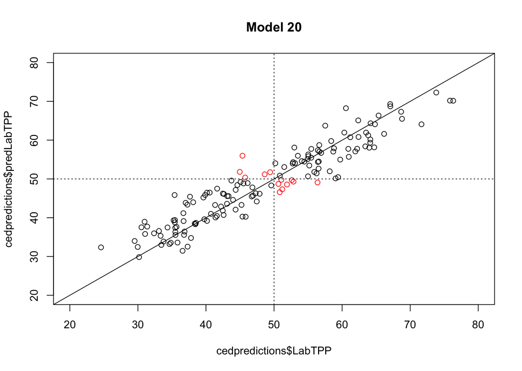

```r
# plot predicted vs actual results
plot(cedpredictions$LabTPP, cedpredictions$predLabTPP, xlim=c(20,80), ylim=c(20,80), main="Model 20", col=ifelse(cedpredictions$predLabTPP>50 & cedpredictions$LabTPP<50, "red",
                ifelse(cedpredictions$predLabTPP<50 & cedpredictions$LabTPP>50, "red", "black")))
abline(0,1)
abline(v=50, lty=3)
abline(h=50, lty=3)
```

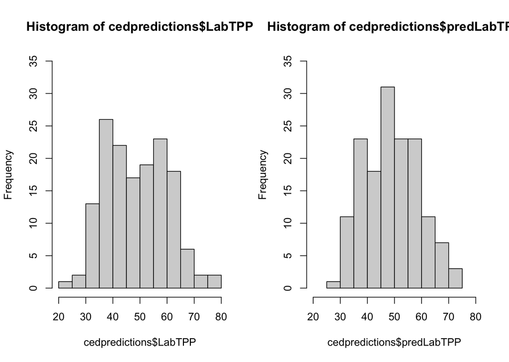

```r
par(mfrow=c(1,2))
hist(cedpredictions$LabTPP, xlim=c(20,80), ylim=c(0,35))
hist(cedpredictions$predLabTPP, xlim=c(20,80), ylim=c(0,35))
```

### Omit electorate random effects from the model

```r
# Estimate model
model.20.A <- glmer(lab2pp.2 ~ age_group4 + ced_2016lab2ppshare.fraction + education + gender +                          country_born + (1|state_name), family=binomial(link="logit"), data=data2)
summary (model.20.A)
```

```
## Generalized linear mixed model fit by maximum likelihood (Laplace
##   Approximation) [glmerMod]
##  Family: binomial  ( logit )
## Formula: lab2pp.2 ~ age_group4 + ced_2016lab2ppshare.fraction + education +
##     gender + country_born + (1 | state_name)
##    Data: data2
##
##      AIC      BIC   logLik deviance df.resid
##   2518.6   2585.4  -1247.3   2494.6     1911
##
## Scaled residuals:
##     Min      1Q  Median      3Q     Max
## -2.5116 -0.8592 -0.5742  0.9496  2.3031
##
## Random effects:
##  Groups     Name        Variance Std.Dev.
##  state_name (Intercept) 0.0311   0.1763
## Number of obs: 1923, groups:  state_name, 8
##
## Fixed effects:
##                                Estimate Std. Error z value Pr(>|z|)
## (Intercept)                  -1.0966867  0.3245851  -3.379 0.000728 ***
## age_group4(34,49]            -0.7610400  0.1889070  -4.029 5.61e-05 ***
## age_group4(49,64]            -0.8092920  0.1785694  -4.532 5.84e-06 ***
## age_group4(64,104]           -1.1272487  0.1754014  -6.427 1.30e-10 ***
## ced_2016lab2ppshare.fraction  3.1199388  0.4644151   6.718 1.84e-11 ***
## education2                    0.0001801  0.1531682   0.001 0.999062
## education3                    0.4093957  0.1325141   3.089 0.002005 **
## education4                   -0.2895967  0.3206934  -0.903 0.366508
## gender2                       0.1957355  0.0977709   2.002 0.045287 *
## country_born2                -0.1767976  0.1177123  -1.502 0.133111
## country_born3                 0.0119247  0.5756427   0.021 0.983473
## ---
## Signif. codes:  0 '***' 0.001 '**' 0.01 '*' 0.05 '.' 0.1 ' ' 1
##
## Correlation of Fixed Effects:
##             (Intr) a_4(34 a_4(49 a_4(64 c_2016 edctn2 edctn3 edctn4 gendr2
## ag_4(34,49] -0.389
## ag_4(49,64] -0.454  0.716
## a_4(64,104] -0.503  0.724  0.783
## cd_2016lb2. -0.751  0.013  0.040  0.053
## education2  -0.276 -0.007 -0.027  0.026 -0.006
## education3  -0.338 -0.067 -0.003  0.084  0.027  0.640
## education4  -0.091 -0.004 -0.002 -0.009 -0.032  0.258  0.296
## gender2     -0.198  0.025  0.068  0.114 -0.038  0.117  0.057  0.002
## contry_brn2  0.022 -0.020 -0.042 -0.070 -0.096  0.003 -0.064  0.016  0.069
## contry_brn3 -0.027  0.015  0.016  0.009  0.009 -0.003 -0.007 -0.020  0.012
##             cntr_2
## ag_4(34,49]
## ag_4(49,64]
## a_4(64,104]
## cd_2016lb2.
## education2
## education3
## education4
## gender2
## contry_brn2
## contry_brn3  0.044
```

```r
ranef(model.20.A)
```

```
## $state_name
##     (Intercept)
## ACT  0.22694101
## NSW  0.04049599
## NT  -0.02932764
## QLD -0.23760880
## SA  -0.03551745
## TAS -0.01502939
## VIC  0.09948138
## WA  -0.04918549
##
## with conditional variances for "state_name"
```

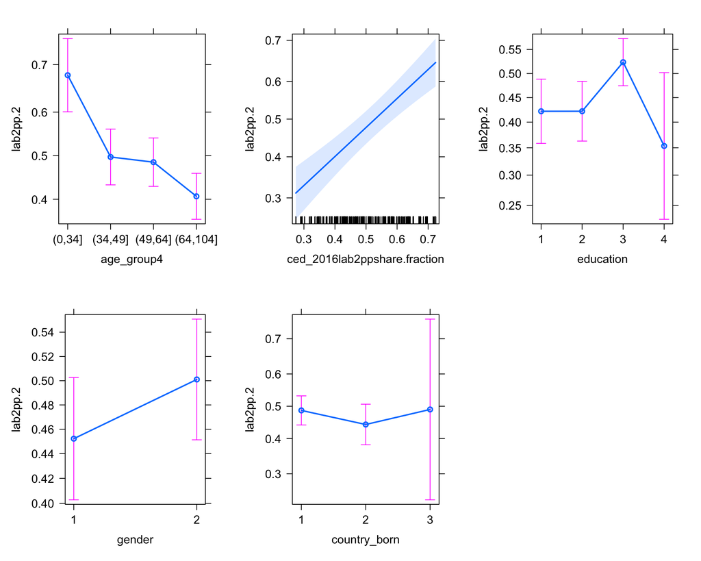

```r
# plot fixed effects
library("effects")
plot(predictorEffects(model.20.A), main="")
```

### Interpreting model 20.A

The coefficients and plots show:

- Age: People aged 18-34 had a 68 per cent probability of voting 2PP Labor; this fell to around 50 per cent for those aged 35-49, around 49 per cent for those 50-64 and 40 per cent for those aged 65 and over.
- Education: People whose highest educational level was school or post-school qualifications such as trades had a 40 per cent probablity of voting Labor wh=ile those with university educations had a 52 per cent probablity (and those who did not indicate their education level had a 35 per cent probability of voting Labor)
- Gender: Males had a 45 per cent probability of voting Labor while females had a 50 per cent probability
- Country of birth: Australian-born respondents had a 49 per cent probability of voting Labor while those born outside Australia had a 44 per cent probability (and those who did not respond to the question on country of birth had a 49 per cent probability)
- 2016 vote: For every one percentage point increase in a voter’s electorate’s 2016 Labor TPP vote, there was a 0.78 percentage point increase in the voter’s probability of voting Labor in 2016.
- The values of the intercepts are difficult to interpret. The fixed intercept of -1.10 can be interpreted as the mean of the (logit of the) Labor 2PP dependent variable for all voters in the AES survey when the value of Labor’s 2016 2PP vote share is zero and for a voter who is male, has school level education, is aged 18-34 and born in Australia. The intercepts for the state random effects can be interpreted as the means of the dependent variable (for this deomgraphic “reference case” voter) across voters in each of the state groups or clusters. These state intercepts range from +0.23 for the ACT, (indicating that a voter in the ACT is 5.5 percentage points more likely to vote 2PP Labor than the mean across the whole sample for the demographic reference case voter) to -0.24 for Queensland (indicating Queenslanders were 6 percentage points less likely to vote 2PP Labor compared to the sample-wide average average).

```r
# post-stratify
cellpredictions.A <- invlogit (fixef(model.20.A)["(Intercept)"]
    + (fixef(model.20.A)["age_group4(34,49]"]*census3$cage_group4.34.49)
    + (fixef(model.20.A)["age_group4(49,64]"]*census3$cage_group4.49.64)
    + (fixef(model.20.A)["age_group4(64,104]"]*census3$cage_group4.64.104)
    + (fixef(model.20.A)["ced_2016lab2ppshare.fraction"]*census3$cced_2016lab2ppshare.fraction)
    + (fixef(model.20.A)["education2"]*census3$ceducation2)
    + (fixef(model.20.A)["education3"]*census3$ceducation3)
    + (fixef(model.20.A)["education4"]*census3$ceducation4)
    + (fixef(model.20.A)["gender2"]*census3$cgender2)
    + (fixef(model.20.A)["country_born2"]*census3$ccountry_born2)
    + (fixef(model.20.A)["country_born3"]*census3$ccountry_born3)
    + ranef(model.20.A)$state_name[census3$cstate_name,1])
# Weight cell predictions by population frequency of each cell (per CED)
cellpredictions.A.weighted <- cellpredictions.A*census3$cpercent.ced
# Sum the weighted cell predictions for all cells in each CED
cedpredictions.A <- 100*as.table(tapply(cellpredictions.A.weighted, census3$cced_name, sum))
# export to csv file
write.csv(cedpredictions.A, file = "cedpredict.model20.A.csv")
```

### Model 20.A results

```r
cedpredictions.A <- as.data.frame(cedpredictions.A)
cedpredictions.A <- cedpredictions.A %>%
                     rename(
                       ced = Var1,
                       predLabTPP = Freq
                       )
cedpredictions.A$predLabwin <- ifelse(cedpredictions.A$predLabTPP>50,1,0)
# join the predicted and actual election results
cedpredictions.A <- merge(cedpredictions.A, outcomes, by = "ced")
cedpredictions.A$abserror <- abs(cedpredictions.A$predLabTPP-cedpredictions.A$LabTPP)
# calculate results metrics
MAPE.A <- round(mean(cedpredictions.A$abserror), digits=2)
maxerror.A <- round(max(cedpredictions.A$abserror), digits=2)
predLabwin.A <- sum(cedpredictions.A$predLabwin)-2
predcorrect.A <- sum(ifelse(cedpredictions.A$predLabwin==cedpredictions.A$Labwin,1,0))
# put metrics into a data frame
metrics.A <- as.data.frame(rbind(c("Model 20.A", MAPE.A, maxerror.A, predLabwin.A, predcorrect.A)))
colnames(metrics.A) <- c("", "Mean absolute error (ppts)", "Max error (ppts)", "Predicted Labor wins", "Correct win predictions")
# display results table
kable(metrics.A, caption="**Model 20.A (omits CED random effects)**", digits=2)
```

**Model 20.A (omits CED random effects)**

|  | Mean absolute error (ppts) | Max error (ppts) | Predicted Labor wins | Correct win predictions |
| --- | --- | --- | --- | --- |
| Model 20.A | 2.74 | 8.65 | 64 | 141 |

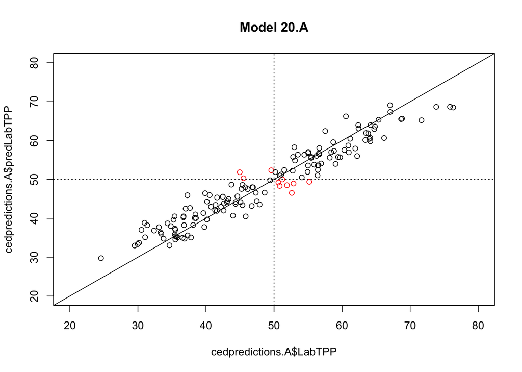

```r
# plot predicted vs actual results
plot(cedpredictions.A$LabTPP, cedpredictions.A$predLabTPP, xlim=c(20,80), ylim=c(20,80), main="Model 20.A",
     col=ifelse(cedpredictions.A$predLabTPP>50 & cedpredictions.A$LabTPP<50, "red",
                ifelse(cedpredictions.A$predLabTPP<50 & cedpredictions.A$LabTPP>50, "red", "black")))
abline(0,1)
abline(v=50, lty=3)
abline(h=50, lty=3)
```

### Results summary

Using a specification of model 20 which omits electorates as a random effect in the model results in electorate TPP predictions with a mean absolute percentage error of 2.74 ppts. Correct win/loss predictions are made in 141 of the 151 seats. Labor is predicted to win more than 50 per cent of the TPP vote in 66 seats (this includes Clark and Melbourne). The maximum error is 8.7 ppts and there are 24 electorates with an error greater than 5.0 ppts.

### Gender x age

```r
# Gender x age interaction
model.20.B <- glmer(lab2pp.2 ~ age_group4 + ced_2016lab2ppshare.fraction + education + gender +                          country_born + age_group4:gender + (1|state_name), family=binomial(link="logit"),                       data=data2)
# post-stratify
cellpredictions.B <- invlogit (fixef(model.20.B)["(Intercept)"]
    + (fixef(model.20.B)["age_group4(34,49]"]*census3$cage_group4.34.49)
    + (fixef(model.20.B)["age_group4(49,64]"]*census3$cage_group4.49.64)
    + (fixef(model.20.B)["age_group4(64,104]"]*census3$cage_group4.64.104)
    + (fixef(model.20.B)["ced_2016lab2ppshare.fraction"]*census3$cced_2016lab2ppshare.fraction)
    + (fixef(model.20.B)["education2"]*census3$ceducation2)
    + (fixef(model.20.B)["education3"]*census3$ceducation3)
    + (fixef(model.20.B)["education4"]*census3$ceducation4)
    + (fixef(model.20.B)["gender2"]*census3$cgender2)
    + (fixef(model.20.B)["country_born2"]*census3$ccountry_born2)
    + (fixef(model.20.B)["country_born3"]*census3$ccountry_born3)
    + (fixef(model.20.B)["age_group4(34,49]:gender2"]*census3$cgender2*census3$cage_group4.34.49)
    + (fixef(model.20.B)["age_group4(49,64]:gender2"]*census3$cgender2*census3$cage_group4.49.64)
    + (fixef(model.20.B)["age_group4(64,104]:gender2"]*census3$cgender2*census3$cage_group4.64.104)
    + ranef(model.20.B)$state_name[census3$cstate_name,1])
# Weight cell predictions by population frequency of each cell (per CED)
cellpredictions.B.weighted <- cellpredictions.B*census3$cpercent.ced
# Sum the weighted cell predictions for all cells in each CED
cedpredictions.B <- 100*as.table(tapply(cellpredictions.B.weighted, census3$cced_name, sum))
```

### Model 20.B results

```r
cedpredictions.B <- as.data.frame(cedpredictions.B)
cedpredictions.B <- cedpredictions.B %>%
                     rename(
                       ced = Var1,
                       predLabTPP = Freq
                       )
cedpredictions.B$predLabwin <- ifelse(cedpredictions.B$predLabTPP>50,1,0)
# join the predicted and actual election results
cedpredictions.B <- merge(cedpredictions.B, outcomes, by = "ced")
cedpredictions.B$abserror <- abs(cedpredictions.B$predLabTPP-cedpredictions.B$LabTPP)
# calculate results metrics
MAPE.B <- round(mean(cedpredictions.B$abserror), digits=2)
maxerror.B <- round(max(cedpredictions.B$abserror), digits=2)
predLabwin.B <- sum(cedpredictions.B$predLabwin)-2
predcorrect.B <- sum(ifelse(cedpredictions.B$predLabwin==cedpredictions.B$Labwin,1,0))
# put metrics into a data frame
metrics.B <- as.data.frame(rbind(c("Model 20.B", MAPE.B, maxerror.B, predLabwin.B, predcorrect.B)))
colnames(metrics.B) <- c("", "Mean absolute error (ppts)", "Max error (ppts)", "Predicted Labor wins", "Correct win predictions")
# display results table
kable(metrics.B, caption="**Model 20.B (adds gender:age interaction)**", digits=2)
```

**Model 20.B (adds gender:age interaction)**

|  | Mean absolute error (ppts) | Max error (ppts) | Predicted Labor wins | Correct win predictions |
| --- | --- | --- | --- | --- |
| Model 20.B | 2.74 | 8.5 | 64 | 141 |

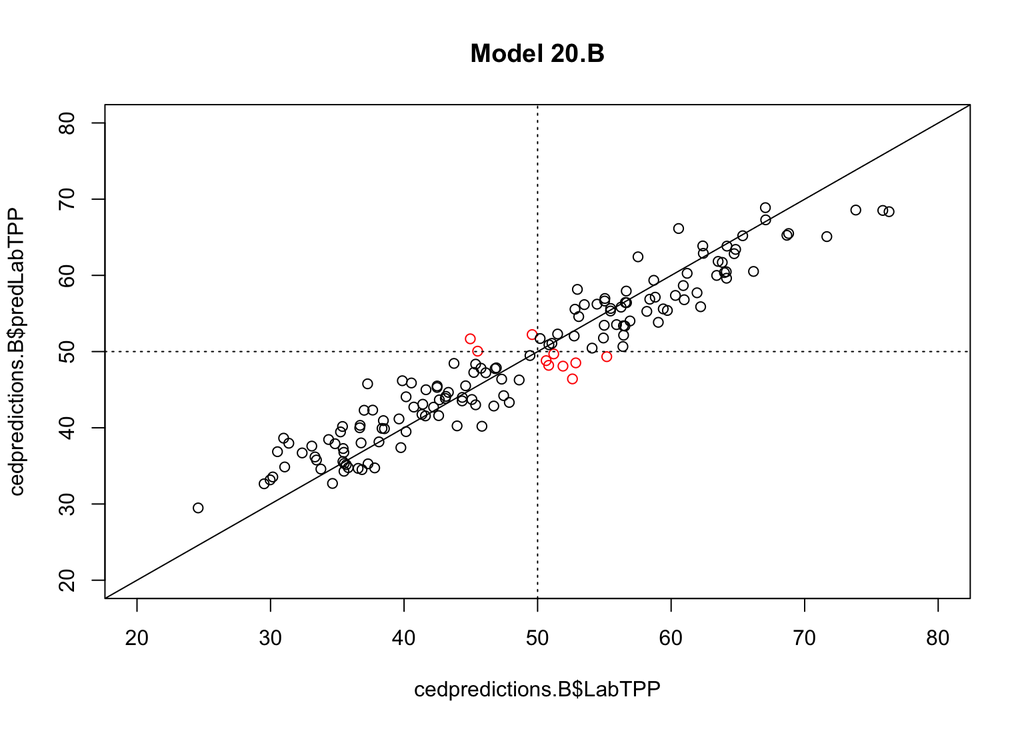

```r
# plot predicted vs actual results
plot(cedpredictions.B$LabTPP, cedpredictions.B$predLabTPP, xlim=c(20,80), ylim=c(20,80), main="Model 20.B",
     col=ifelse(cedpredictions.B$predLabTPP>50 & cedpredictions.B$LabTPP<50, "red",
                ifelse(cedpredictions.B$predLabTPP<50 & cedpredictions.B$LabTPP>50, "red", "black")))
abline(0,1)
abline(v=50, lty=3)
abline(h=50, lty=3)
```

### Gender x education

```r
# Gender x education interaction
model.20.C <- glmer(lab2pp.2 ~ age_group4 + ced_2016lab2ppshare.fraction + education + gender +                          country_born + education:gender + (1|state_name), family=binomial(link="logit"),                           data=data2)
# post-stratify
cellpredictions.C <- invlogit (fixef(model.20.C)["(Intercept)"]
    + (fixef(model.20.C)["age_group4(34,49]"]*census3$cage_group4.34.49)
    + (fixef(model.20.C)["age_group4(49,64]"]*census3$cage_group4.49.64)
    + (fixef(model.20.C)["age_group4(64,104]"]*census3$cage_group4.64.104)
    + (fixef(model.20.C)["ced_2016lab2ppshare.fraction"]*census3$cced_2016lab2ppshare.fraction)
    + (fixef(model.20.C)["education2"]*census3$ceducation2)
    + (fixef(model.20.C)["education3"]*census3$ceducation3)
    + (fixef(model.20.C)["education4"]*census3$ceducation4)
    + (fixef(model.20.C)["gender2"]*census3$cgender2)
    + (fixef(model.20.C)["country_born2"]*census3$ccountry_born2)
    + (fixef(model.20.C)["country_born3"]*census3$ccountry_born3)
    + (fixef(model.20.C)["education2:gender2"]*census3$cgender2*census3$ceducation2)
    + (fixef(model.20.C)["education3:gender2"]*census3$cgender2*census3$ceducation3)
    + (fixef(model.20.C)["education4:gender2"]*census3$cgender2*census3$ceducation4)
    + ranef(model.20.C)$state_name[census3$cstate_name,1])
# Weight cell predictions by population frequency of each cell (per CED)
cellpredictions.C.weighted <- cellpredictions.C*census3$cpercent.ced
# Sum the weighted cell predictions for all cells in each CED
cedpredictions.C <- 100*as.table(tapply(cellpredictions.C.weighted, census3$cced_name, sum))
```

### Model 20.C results

```r
cedpredictions.C <- as.data.frame(cedpredictions.C)
cedpredictions.C <- cedpredictions.C %>%
                     rename(
                       ced = Var1,
                       predLabTPP = Freq
                       )
cedpredictions.C$predLabwin <- ifelse(cedpredictions.C$predLabTPP>50,1,0)
# join the predicted and actual election results
cedpredictions.C <- merge(cedpredictions.C, outcomes, by = "ced")
cedpredictions.C$abserror <- abs(cedpredictions.C$predLabTPP-cedpredictions.C$LabTPP)
# calculate results metrics
MAPE.C <- round(mean(cedpredictions.C$abserror),digits=2)
maxerror.C <- round(max(cedpredictions.C$abserror), digits=2)
predLabwin.C <- sum(cedpredictions.C$predLabwin)-2
predcorrect.C <- sum(ifelse(cedpredictions.C$predLabwin==cedpredictions.C$Labwin,1,0))
# put metrics into a data frame
metrics.C <- as.data.frame(rbind(c("Model 20.C", MAPE.C, maxerror.C, predLabwin.C, predcorrect.C)))
colnames(metrics.C) <- c("", "Mean absolute error (ppts)", "Max error (ppts)", "Predicted Labor wins", "Correct win predictions")
# display results table
kable(metrics.C, caption="**Model 20.C (gender:education interaction)**", digits=2)
```

**Model 20.C (gender:education interaction)**

|  | Mean absolute error (ppts) | Max error (ppts) | Predicted Labor wins | Correct win predictions |
| --- | --- | --- | --- | --- |
| Model 20.C | 2.76 | 8.9 | 65 | 142 |

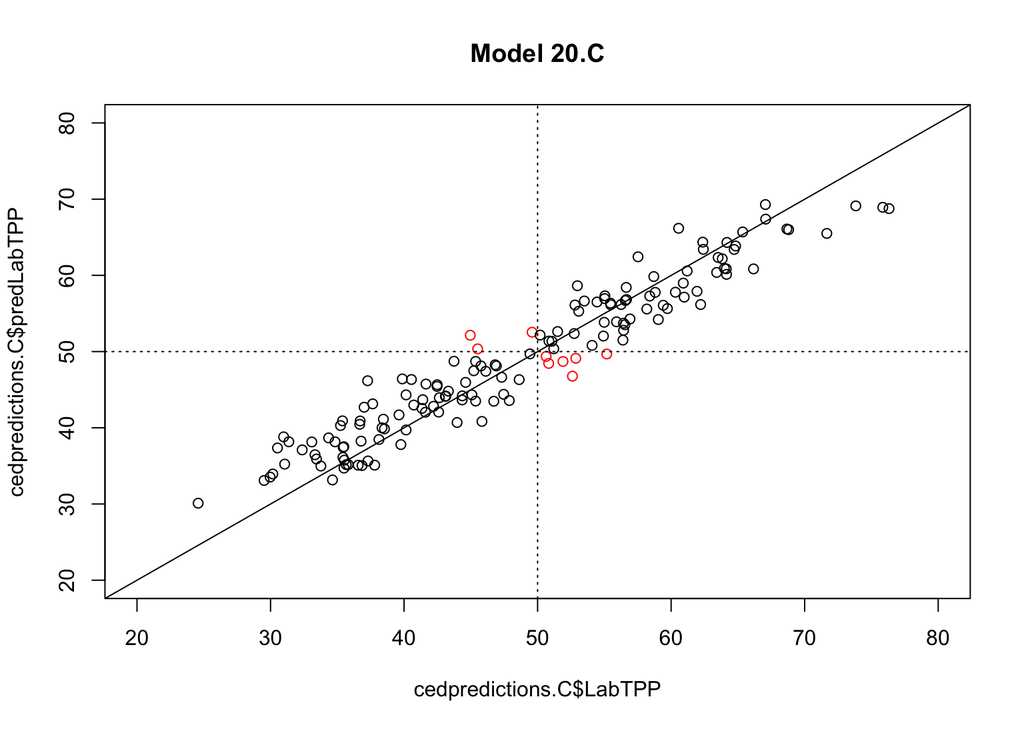

```r
# plot predicted vs actual results
plot(cedpredictions.C$LabTPP, cedpredictions.C$predLabTPP, xlim=c(20,80), ylim=c(20,80), main="Model 20.C",
     col=ifelse(cedpredictions.C$predLabTPP>50 & cedpredictions.C$LabTPP<50, "red",
                ifelse(cedpredictions.C$predLabTPP<50 & cedpredictions.C$LabTPP>50, "red", "black")))
abline(0,1)
abline(v=50, lty=3)
abline(h=50, lty=3)
```

### Education x age

```r
model.20.D <- glmer(lab2pp.2 ~ age_group4 + ced_2016lab2ppshare.fraction + education + gender +                          country_born + education:age_group4 + (1|state_name), family=binomial(link="logit"),                           data=data2)
summary(model.20.D)
```

```
## Generalized linear mixed model fit by maximum likelihood (Laplace
##   Approximation) [glmerMod]
##  Family: binomial  ( logit )
## Formula: lab2pp.2 ~ age_group4 + ced_2016lab2ppshare.fraction + education +
##     gender + country_born + education:age_group4 + (1 | state_name)
##    Data: data2
##
##      AIC      BIC   logLik deviance df.resid
##   2516.7   2633.5  -1237.3   2474.7     1902
##
## Scaled residuals:
##     Min      1Q  Median      3Q     Max
## -2.2844 -0.8644 -0.4984  0.9291  2.4184
##
## Random effects:
##  Groups     Name        Variance Std.Dev.
##  state_name (Intercept) 0.03418  0.1849
## Number of obs: 1923, groups:  state_name, 8
##
## Fixed effects:
##                               Estimate Std. Error z value Pr(>|z|)
## (Intercept)                   -0.85424    0.46967  -1.819   0.0689 .
## age_group4(34,49]             -0.63188    0.51747  -1.221   0.2221
## age_group4(49,64]             -0.63251    0.44888  -1.409   0.1588
## age_group4(64,104]            -1.74988    0.41978  -4.169 3.06e-05 ***
## ced_2016lab2ppshare.fraction   3.16430    0.46721   6.773 1.26e-11 ***
## education2                     0.08791    0.53426   0.165   0.8693
## education3                    -0.08458    0.43214  -0.196   0.8448
## education4                     0.57712    1.23455   0.467   0.6402
## gender2                        0.21437    0.09867   2.173   0.0298 *
## country_born2                 -0.19630    0.11868  -1.654   0.0981 .
## country_born3                  0.07863    0.58017   0.136   0.8922
## age_group4(34,49]:education2  -0.46231    0.70389  -0.657   0.5113
## age_group4(49,64]:education2  -0.56411    0.60541  -0.932   0.3514
## age_group4(64,104]:education2  0.21763    0.57974   0.375   0.7074
## age_group4(34,49]:education3   0.02441    0.56484   0.043   0.9655
## age_group4(49,64]:education3  -0.03994    0.50058  -0.080   0.9364
## age_group4(64,104]:education3  1.06010    0.47521   2.231   0.0257 *
## age_group4(34,49]:education4  -0.65822    1.59099  -0.414   0.6791
## age_group4(49,64]:education4  -1.86232    1.43317  -1.299   0.1938
## age_group4(64,104]:education4 -0.59263    1.30742  -0.453   0.6503
## ---
## Signif. codes:  0 '***' 0.001 '**' 0.01 '*' 0.05 '.' 0.1 ' ' 1
```

```
##
## Correlation matrix not shown by default, as p = 20 > 12.
## Use print(x, correlation=TRUE)  or
##     vcov(x)        if you need it
```

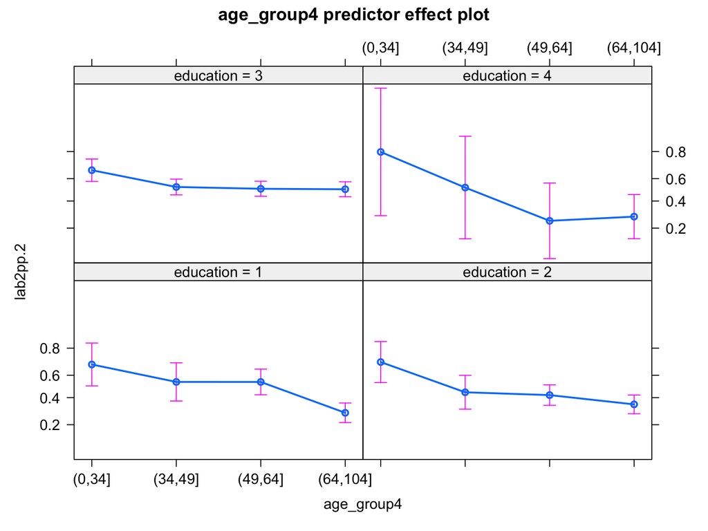

```r
# plot fixed effects
library("effects")
plot(predictorEffects(model.20.D), selection=1)
```

### Interpreting interaction effect

```r
# post stratify
cellpredictions.D <- invlogit (fixef(model.20.C)["(Intercept)"]
    + (fixef(model.20.D)["age_group4(34,49]"]*census3$cage_group4.34.49)
    + (fixef(model.20.D)["age_group4(49,64]"]*census3$cage_group4.49.64)
    + (fixef(model.20.D)["age_group4(64,104]"]*census3$cage_group4.64.104)
    + (fixef(model.20.D)["ced_2016lab2ppshare.fraction"]*census3$cced_2016lab2ppshare.fraction)
    + (fixef(model.20.D)["education2"]*census3$ceducation2)
    + (fixef(model.20.D)["education3"]*census3$ceducation3)
    + (fixef(model.20.D)["education4"]*census3$ceducation4)
    + (fixef(model.20.D)["gender2"]*census3$cgender2)
    + (fixef(model.20.D)["country_born2"]*census3$ccountry_born2)
    + (fixef(model.20.D)["country_born3"]*census3$ccountry_born3)
    + (fixef(model.20.D)["age_group4(34,49]:education2"]*census3$cage_group4.34.49*census3$ceducation2)
    + (fixef(model.20.D)["age_group4(34,49]:education2"]*census3$cage_group4.34.49*census3$ceducation2)
     + (fixef(model.20.D)["age_group4(49,64]:education2"]*census3$cage_group4.49.64*census3$ceducation2)
     + (fixef(model.20.D)["age_group4(64,104]:education2"]*census3$cage_group4.64.104*census3$ceducation2)
     + (fixef(model.20.D)["age_group4(34,49]:education3"]*census3$cage_group4.34.49*census3$ceducation3)
     + (fixef(model.20.D)["age_group4(49,64]:education3"]*census3$cage_group4.49.64*census3$ceducation3)
     + (fixef(model.20.D)["age_group4(64,104]:education3"]*census3$cage_group4.64.104*census3$ceducation3)
     + (fixef(model.20.D)["age_group4(34,49]:education4"]*census3$cage_group4.34.49*census3$ceducation4)
     + (fixef(model.20.D)["age_group4(49,64]:education4"]*census3$cage_group4.49.64*census3$ceducation4)
    + (fixef(model.20.D)["age_group4(64,104]:education4"]*census3$cage_group4.64.104*census3$ceducation4)
    + ranef(model.20.D)$state_name[census3$cstate_name,1])
# Weight cell predictions by population frequency of each cell (per CED)
cellpredictions.D.weighted <- cellpredictions.D*census3$cpercent.ced
# Sum the weighted cell predictions for all cells in each CED
cedpredictions.D <- 100*as.table(tapply(cellpredictions.D.weighted, census3$cced_name, sum))
```

### Model 20.D results

```r
cedpredictions.D <- as.data.frame(cedpredictions.D)
cedpredictions.D <- cedpredictions.D %>%
                     rename(
                       ced = Var1,
                       predLabTPP = Freq
                       )
cedpredictions.D$predLabwin <- ifelse(cedpredictions.D$predLabTPP>50,1,0)
# join the predicted and actual election results
cedpredictions.D <- merge(cedpredictions.D, outcomes, by = "ced")
cedpredictions.D$abserror <- abs(cedpredictions.D$predLabTPP-cedpredictions.D$LabTPP)
# calculate results metrics
MAPE.D <- round(mean(cedpredictions.D$abserror), digits=2)
maxerror.D <- round(max(cedpredictions.D$abserror), digits=2)
predLabwin.D <- sum(cedpredictions.D$predLabwin)-2
predcorrect.D <- sum(ifelse(cedpredictions.D$predLabwin==cedpredictions.D$Labwin,1,0))
# put metrics into a data frame
metrics.D <- as.data.frame(rbind(c("Model 20.D", MAPE.D, maxerror.D, predLabwin.D, predcorrect.D)))
colnames(metrics.D) <- c("", "Mean absolute error (ppts)", "Max error (ppts)", "Predicted Labor wins", "Correct win predictions")
# display results table
kable(metrics.D, caption="**Model 20.D (education:age interaction)**", digits=2)
```

**Model 20.D (education:age interaction)**

|  | Mean absolute error (ppts) | Max error (ppts) | Predicted Labor wins | Correct win predictions |
| --- | --- | --- | --- | --- |
| Model 20.D | 3.17 | 10.1 | 70 | 143 |

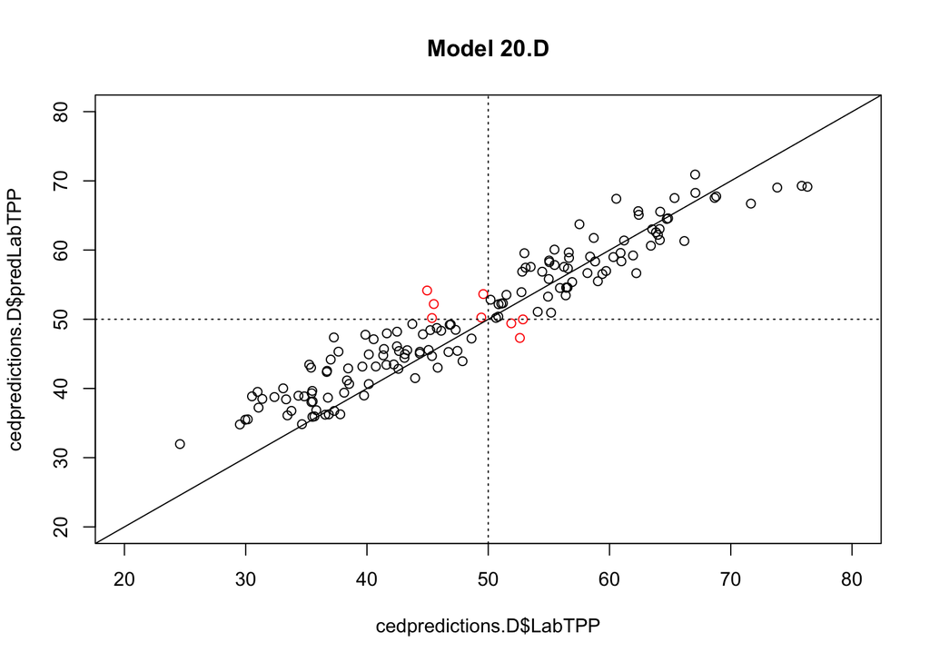

```r
# plot predicted vs actual results
plot(cedpredictions.D$LabTPP, cedpredictions.D$predLabTPP, xlim=c(20,80), ylim=c(20,80), main="Model 20.D",
     col=ifelse(cedpredictions.D$predLabTPP>50 & cedpredictions.D$LabTPP<50, "red",
                ifelse(cedpredictions.D$predLabTPP<50 & cedpredictions.D$LabTPP>50, "red", "black")))
abline(0,1)
abline(v=50, lty=3)
abline(h=50, lty=3)
```

## Exclude 2016 voteshare as fixed effect, inlcude CED random effect

```r
# Estimate model
model.20.E <- glmer(lab2pp.2 ~ age_group4 + education + gender + country_born + (1|state_name) + (1|ced_name), family=binomial(link="logit"), data=data2)
# Generate cell predictions
cellpredictions.E <- invlogit (fixef(model.20.E)["(Intercept)"]
    + (fixef(model.20.E)["age_group4(34,49]"]*census3$cage_group4.34.49)
    + (fixef(model.20.E)["age_group4(49,64]"]*census3$cage_group4.49.64)
    + (fixef(model.20.E)["age_group4(64,104]"]*census3$cage_group4.64.104)
    + (fixef(model.20.E)["education2"]*census3$ceducation2)
    + (fixef(model.20.E)["education3"]*census3$ceducation3)
    + (fixef(model.20.E)["education4"]*census3$ceducation4)
    + (fixef(model.20.E)["gender2"]*census3$cgender2)
    + (fixef(model.20.E)["country_born2"]*census3$ccountry_born2)
    + (fixef(model.20.E)["country_born3"]*census3$ccountry_born3)
    + ranef(model.20.E)$state_name[census3$cstate_name,1]
    + ranef(model.20.E)$ced_name[census3$cced_name,1])
# Weight cell predictions by population frequency of each cell (per CED)
cellpredictions.E.weighted <- cellpredictions.E*census3$cpercent.ced
# Sum the weighted cell predictions for all cells in each CED
cedpredictions.E <- 100*as.table(tapply(cellpredictions.E.weighted, census3$cced_name, sum))
```

## Model 20.E results

```r
cedpredictions.E <- as.data.frame(cedpredictions.E)
cedpredictions.E <- cedpredictions.E %>%
                     rename(
                       ced = Var1,
                       predLabTPP = Freq
                       )
cedpredictions.E$predLabwin <- ifelse(cedpredictions.E$predLabTPP>50,1,0)
# join the predicted and actual election results
cedpredictions.E <- merge(cedpredictions.E, outcomes, by = "ced")
cedpredictions.E$abserror <- abs(cedpredictions.E$predLabTPP-cedpredictions.E$LabTPP)
# calculate results metrics
MAPE.E <- round(mean(cedpredictions.E$abserror), digits=2)
maxerror.E <- round(max(cedpredictions.E$abserror), digits=2)
predLabwin.E <- sum(cedpredictions.E$predLabwin)-2
predcorrect.E <- sum(ifelse(cedpredictions.E$predLabwin==cedpredictions.E$Labwin,1,0))
# put metrics into a data frame
metrics.E <- as.data.frame(rbind(c("Model 20.E", MAPE.E, maxerror.E, predLabwin.E, predcorrect.E)))
colnames(metrics.E) <- c("", "Mean absolute error (ppts)", "Max error (ppts)", "Predicted Labor wins", "Correct win predictions")
# display results table
kable(metrics.E, caption="**Model 20.E (omi 2016 vote as fixed effect)**", digits=2)
```

**Model 20.E (omi 2016 vote as fixed effect)**

|  | Mean absolute error (ppts) | Max error (ppts) | Predicted Labor wins | Correct win predictions |
| --- | --- | --- | --- | --- |
| Model 20.E | 7.53 | 20.94 | 72 | 113 |

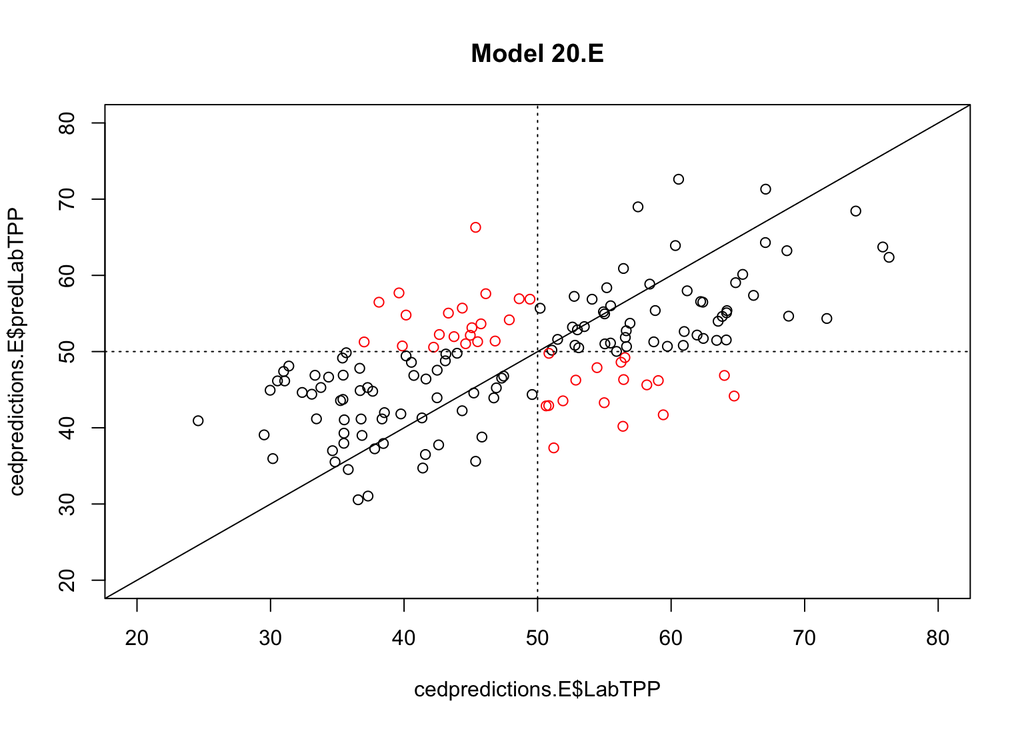

```r
# plot predicted vs actual results
plot(cedpredictions.E$LabTPP, cedpredictions.E$predLabTPP, xlim=c(20,80), ylim=c(20,80), main="Model 20.E",
     col=ifelse(cedpredictions.E$predLabTPP>50 & cedpredictions.E$LabTPP<50, "red",
                ifelse(cedpredictions.E$predLabTPP<50 & cedpredictions.E$LabTPP>50, "red", "black")))
abline(0,1)
abline(v=50, lty=3)
abline(h=50, lty=3)
```

### Overall results table and plot

```r
metricsall <- rbind(metrics, metrics.A, metrics.B, metrics.C, metrics.D, metrics.E)
kable(metricsall, caption="**Results summary**", digits=2)
```

**Results summary**

|  | Mean absolute error (ppts) | Max error (ppts) | Predicted Labor wins | Correct win predictions |
| --- | --- | --- | --- | --- |
| Model 20 | 3.14 | 10.62 | 65 | 138 |
| Model 20.A | 2.74 | 8.65 | 64 | 141 |
| Model 20.B | 2.74 | 8.5 | 64 | 141 |
| Model 20.C | 2.76 | 8.9 | 65 | 142 |
| Model 20.D | 3.17 | 10.1 | 70 | 143 |
| Model 20.E | 7.53 | 20.94 | 72 | 113 |

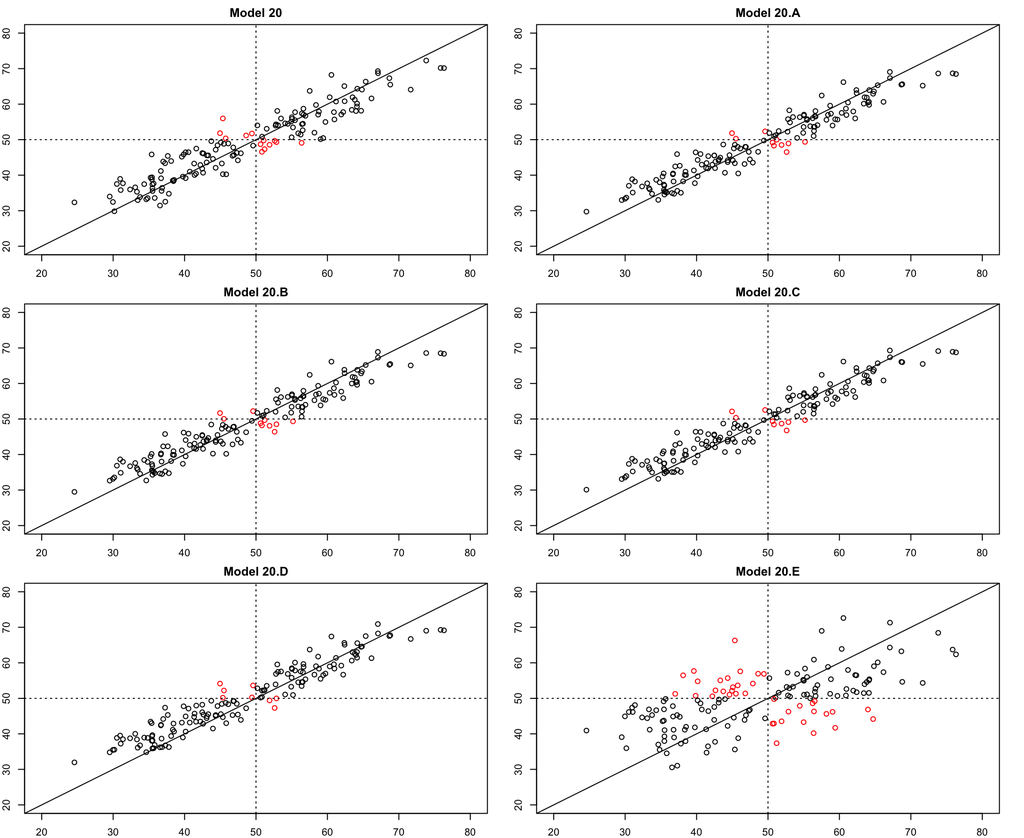

```r
par(mar=rep(2,4)) # reduces size of margins
par(mfrow=c(3,2))
plot(cedpredictions$LabTPP, cedpredictions$predLabTPP, xlim=c(20,80), ylim=c(20,80), main="Model 20", xlab="", ylab="", col=ifelse(cedpredictions$predLabTPP>50 & cedpredictions$LabTPP<50, "red",
                ifelse(cedpredictions$predLabTPP<50 & cedpredictions$LabTPP>50, "red", "black")))
abline(0,1)
abline(v=50, lty=3)
abline(h=50, lty=3)

plot(cedpredictions.A$LabTPP, cedpredictions.A$predLabTPP, xlim=c(20,80), ylim=c(20,80), main="Model 20.A",
     xlab="", ylab="", col=ifelse(cedpredictions.A$predLabTPP>50 & cedpredictions.A$LabTPP<50, "red",
                ifelse(cedpredictions.A$predLabTPP<50 & cedpredictions.A$LabTPP>50, "red", "black")))
abline(0,1)
abline(v=50, lty=3)
abline(h=50, lty=3)

plot(cedpredictions.B$LabTPP, cedpredictions.B$predLabTPP, xlim=c(20,80), ylim=c(20,80), main="Model 20.B",
     xlab="", ylab="", col=ifelse(cedpredictions.B$predLabTPP>50 & cedpredictions.B$LabTPP<50, "red",
                ifelse(cedpredictions.B$predLabTPP<50 & cedpredictions.B$LabTPP>50, "red", "black")))
abline(0,1)
abline(v=50, lty=3)
abline(h=50, lty=3)

plot(cedpredictions.C$LabTPP, cedpredictions.C$predLabTPP, xlim=c(20,80), ylim=c(20,80), main="Model 20.C",
     xlab="", ylab="", col=ifelse(cedpredictions.C$predLabTPP>50 & cedpredictions.C$LabTPP<50, "red",
                ifelse(cedpredictions.C$predLabTPP<50 & cedpredictions.C$LabTPP>50, "red", "black")))
abline(0,1)
abline(v=50, lty=3)
abline(h=50, lty=3)

plot(cedpredictions.D$LabTPP, cedpredictions.D$predLabTPP, xlim=c(20,80), ylim=c(20,80), main="Model 20.D",
     xlab="", ylab="", col=ifelse(cedpredictions.D$predLabTPP>50 & cedpredictions.D$LabTPP<50, "red",
                ifelse(cedpredictions.D$predLabTPP<50 & cedpredictions.D$LabTPP>50, "red", "black")))
abline(0,1)
abline(v=50, lty=3)
abline(h=50, lty=3)

plot(cedpredictions.E$LabTPP, cedpredictions.E$predLabTPP, xlim=c(20,80), ylim=c(20,80), main="Model 20.E",
     col=ifelse(cedpredictions.E$predLabTPP>50 & cedpredictions.E$LabTPP<50, "red",
                ifelse(cedpredictions.E$predLabTPP<50 & cedpredictions.E$LabTPP>50, "red", "black")))
abline(0,1)
abline(v=50, lty=3)
abline(h=50, lty=3)
```